# **Homework 5**

#### Imports

```python
import pandas as pd
import numpy as np
import matplotlib.pyplot as plt
import seaborn as sns
import scipy.stats as stats
import statsmodels as sm
import statsmodels.tsa as tsa
from statsmodels.tsa.stattools import adfuller
from statsmodels.tsa.seasonal import seasonal_decompose
import statsmodels.graphics.tsaplots as tsaplots
from statsmodels.tsa.statespace.sarimax import SARIMAX
import prophet
import warnings

warnings.filterwarnings("ignore")
sns.set_theme(style="darkgrid")
pd.set_option('display.float_format', '{:.4f}'.format)
```

## **Question 1**

#### Define DataFrame

```python
q1_data = pd.read_csv('finance_popularity.csv', parse_dates=['month'])
date_range = pd.date_range(start = '2004-01-01',end='2020-01-01',freq='MS')
q1_data.set_index(date_range,inplace=True)
q1_data = q1_data.drop(['month'],axis=1)
```

### 1.a

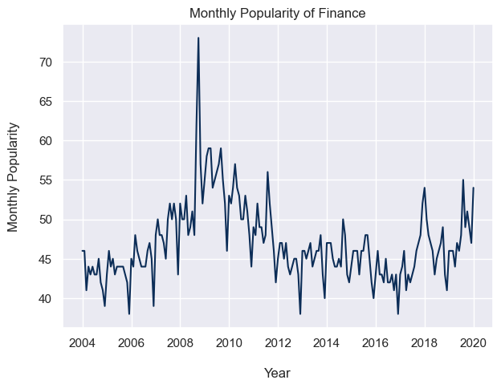

```python
sns.lineplot(data = q1_data, x= q1_data.index , y="finance", linewidth=1.5,color='#0C2D57')
plt.xlabel('\nYear')
plt.ylabel("Monthly Popularity\n")
plt.tight_layout()
plt.title('Monthly Popularity of Finance')
```

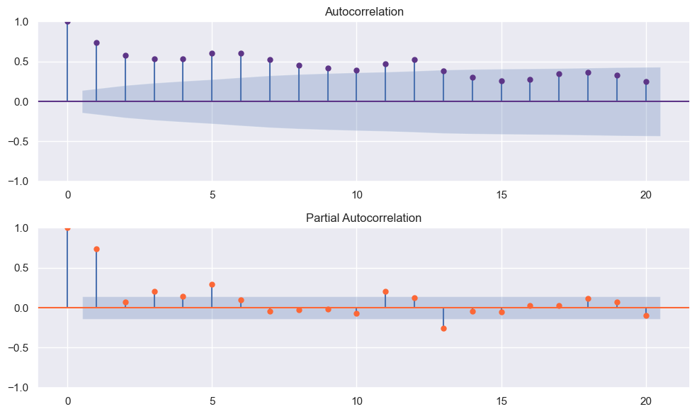

```python
fig, axes = plt.subplots(2,1,figsize=(10, 6))

tsaplots.plot_acf(q1_data, lags=20, color='#5D3587', ax=axes[0])
tsaplots.plot_pacf(q1_data, lags=20, color='#FC6736', ax=axes[1])
plt.tight_layout()
plt.show()
```

For non-stationary data, ACF drops to 0 relatively slowly, because non-stationary data may still appear highly correlated with previous observations, indicating that time component still plays an important role. The diagram above shows the ACF of the original time series data, which decreases slowly thus very likely to be non-stationary.

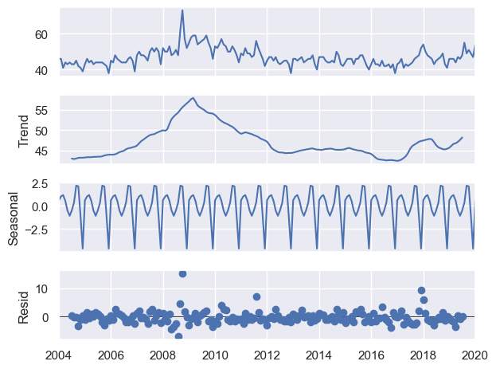

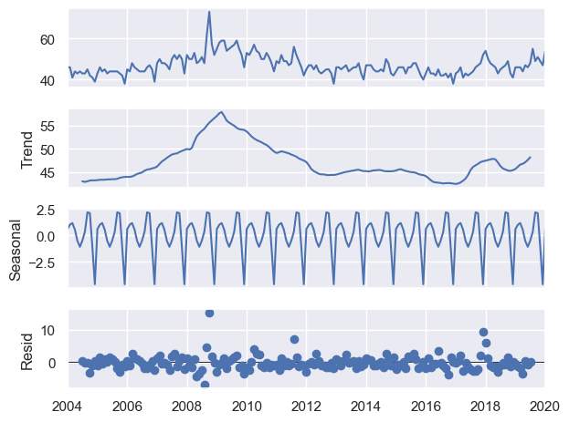

```python
decomposition = seasonal_decompose(x=q1_data, model='additive', period = 12)
decomposition.plot()
```

### 1.b

```python
q1_data_check = q1_data.reset_index()
q1_data_check[q1_data_check['index'].isin(pd.date_range(start = '2008-01-01',end='2010-01-01',freq='MS'))] #.describe()
q1_data_check['finance'] = q1_data_check['finance'].where(q1_data_check['index'] != '2008-10-01',60)
q1_data = q1_data_check
q1_data.set_index('index',inplace=True)
```

```python
def check_stationary(data:pd.DataFrame, decomposition_period = 1):
    sns.lineplot(data = data, x='index' , y="finance", linewidth=1.5,color='#0C2D57')
    plt.xlabel('\nYear')
    plt.ylabel("Monthly Popularity\n")
    plt.tight_layout()
    plt.title('Monthly Popularity of Finance \n(Stationarity)')
    plt.show()

    _, pvalue,_,_,_,_ = adfuller(data['finance'],autolag='AIC')
    print(f"P-value for transformed data stationary check:\n{pvalue}")


    decomposition = seasonal_decompose(x=data['finance'], model='additive', period = decomposition_period)
    decomposition.plot()

    fig, axes = plt.subplots(2,1,figsize=(20, 10))

    tsaplots.plot_acf(data['finance'], lags=60, color='#5D3587', ax=axes[0])
    tsaplots.plot_pacf(data['finance'], lags=60, color='#FC6736', ax=axes[1])
    fig.show()
```

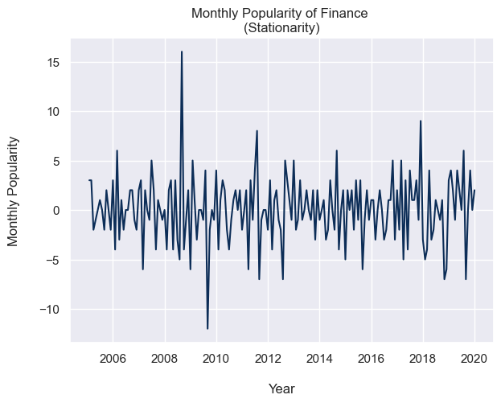

```
P-value for transformed data stationary check:
1.4238895117383722e-06
```

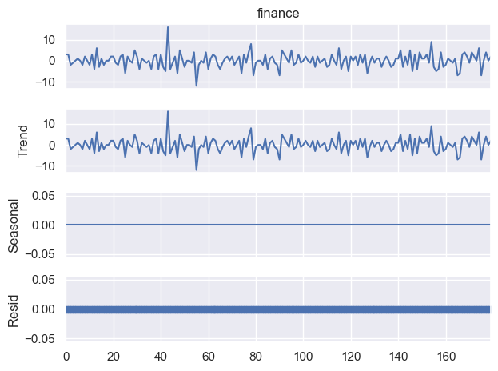

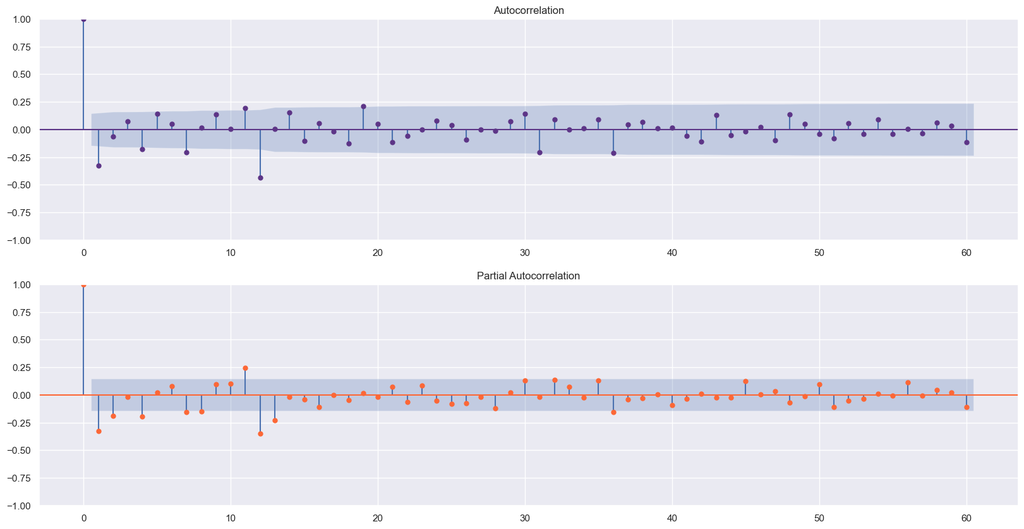

```python
trend_diff = (q1_data.diff(periods=1)).dropna(inplace=False)
seasonal_diff = (trend_diff - trend_diff.shift(12)).dropna(inplace=False)
diff_data = seasonal_diff.reset_index()
check_stationary(diff_data)
```

By using ADF test , we found that p value is far below 0.05. Therefore, it indicates it is highly likely that transformed time series data is stationary.

The visualization above indicates that the time series trend has been limited and its mean values conatants over time, suggesting that the data is stationary. Also seasonality is 0 and residuals are 0.

### 1.c

The figure above (1.b) shows the ACF of transformed time series data, which decreases rapidly to 0 and appear to have constant mean, thus stationary.

We can observe that when lag = 3 the PACF is almost 0. We will select the AR(p)-values by when the PACF falls within the significant threshold (blue area) for the first time, i.e. p = 3. In the lecture we said values should be from the set {0,1,2}, so we will test p = 2 as well. We will select the q-values by when the ACF is first dropping near 0 for the first time, i.e. q = 2. We also tested different parameters for checking, for instance p=12 for autocorrletion was detected after few shots of other values, where the correlogram presented spickes in 12,24,ect..

### 1.d

```python
diff = diff_data['finance']
```

##### Model 1 - SARIMAX (12,2,0) (0,0,0,12)

```
                               SARIMAX Results
==============================================================================
Dep. Variable:                finance   No. Observations:                  180
Model:              SARIMAX(12, 2, 0)   Log Likelihood                -453.162
Date:                Mon, 19 Feb 2024   AIC                            932.324
Time:                        14:36:33   BIC                            973.687
Sample:                             0   HQIC                           949.098
                                - 180
Covariance Type:                  opg
==============================================================================
                 coef    std err          z      P>|z|      [0.025      0.975]
------------------------------------------------------------------------------
ar.L1         -2.1099      0.075    -28.037      0.000      -2.257      -1.962
ar.L2         -2.9283      0.185    -15.850      0.000      -3.290      -2.566
ar.L3         -3.3173      0.297    -11.178      0.000      -3.899      -2.736
ar.L4         -3.5306      0.380     -9.297      0.000      -4.275      -2.786
ar.L5         -3.5011      0.432     -8.096      0.000      -4.349      -2.654
ar.L6         -3.2267      0.463     -6.964      0.000      -4.135      -2.319
ar.L7         -2.8899      0.454     -6.371      0.000      -3.779      -2.001
ar.L8         -2.5209      0.416     -6.064      0.000      -3.336      -1.706
ar.L9         -1.8927      0.362     -5.228      0.000      -2.602      -1.183
ar.L10        -1.0840      0.300     -3.614      0.000      -1.672      -0.496
ar.L11        -0.2612      0.195     -1.337      0.181      -0.644       0.122
ar.L12         0.0022      0.085      0.026      0.979      -0.164       0.168
sigma2         9.0180      0.914      9.863      0.000       7.226      10.810
===================================================================================
Ljung-Box (L1) (Q):                   0.01   Jarque-Bera (JB):                22.63
Prob(Q):                              0.93   Prob(JB):                         0.00
Heteroskedasticity (H):               1.21   Skew:                             0.33
Prob(H) (two-sided):                  0.47   Kurtosis:                         4.62
===================================================================================

Warnings:
[1] Covariance matrix calculated using the outer product of gradients (complex-step).
```

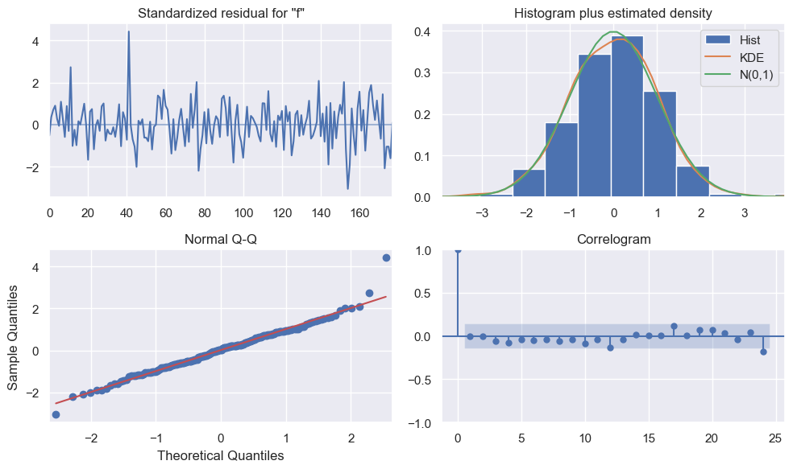

```python
model_1 = SARIMAX(diff, order=(12, 2, 0), seasonal_order=(0, 0,0, 12))
model_1 = model_1.fit(disp=False)
print(model_1.summary())

model_1.plot_diagnostics(lags=24,figsize=(10, 6))
plt.tight_layout()
plt.show()
```

##### Model 2 - SARIMAX (12,1,0) (0,0,0,12)

```
                               SARIMAX Results
==============================================================================
Dep. Variable:                finance   No. Observations:                  180
Model:              SARIMAX(12, 1, 0)   Log Likelihood                -440.544
Date:                Mon, 19 Feb 2024   AIC                            907.089
Time:                        14:36:40   BIC                            948.525
Sample:                             0   HQIC                           923.891
                                - 180
Covariance Type:                  opg
==============================================================================
                 coef    std err          z      P>|z|      [0.025      0.975]
------------------------------------------------------------------------------
ar.L1         -1.2818      0.082    -15.678      0.000      -1.442      -1.122
ar.L2         -1.2548      0.129     -9.755      0.000      -1.507      -1.003
ar.L3         -1.0443      0.160     -6.523      0.000      -1.358      -0.731
ar.L4         -1.0045      0.166     -6.053      0.000      -1.330      -0.679
ar.L5         -0.8408      0.187     -4.491      0.000      -1.208      -0.474
ar.L6         -0.6352      0.197     -3.225      0.001      -1.021      -0.249
ar.L7         -0.5700      0.192     -2.965      0.003      -0.947      -0.193
ar.L8         -0.4924      0.204     -2.418      0.016      -0.892      -0.093
ar.L9         -0.1520      0.203     -0.747      0.455      -0.551       0.247
ar.L10         0.1668      0.170      0.979      0.328      -0.167       0.501
ar.L11         0.3994      0.120      3.341      0.001       0.165       0.634
ar.L12         0.0977      0.087      1.128      0.259      -0.072       0.267
sigma2         7.7998      0.768     10.159      0.000       6.295       9.305
===================================================================================
Ljung-Box (L1) (Q):                   0.03   Jarque-Bera (JB):                37.03
Prob(Q):                              0.86   Prob(JB):                         0.00
Heteroskedasticity (H):               1.19   Skew:                             0.65
Prob(H) (two-sided):                  0.50   Kurtosis:                         4.81
===================================================================================

Warnings:
[1] Covariance matrix calculated using the outer product of gradients (complex-step).
```

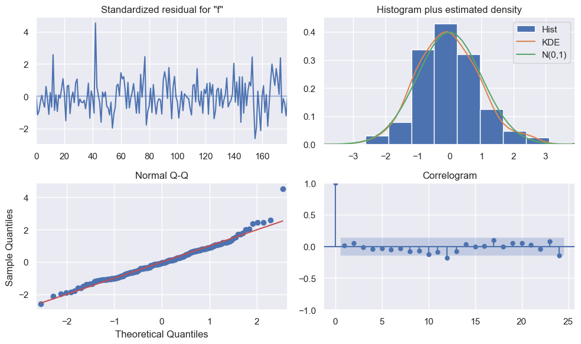

```python
model_2 =SARIMAX(diff, order=(12, 1, 0), seasonal_order=(0, 0,0, 12))
model_2 = model_2.fit(disp=False)
print(model_2.summary())

model_2.plot_diagnostics(lags=24,figsize=(10, 6))
plt.tight_layout()
plt.show()
```

##### Model 3 - SARIMAX (12,0,0) (0,0,0,12)

```
                               SARIMAX Results
==============================================================================
Dep. Variable:                finance   No. Observations:                  180
Model:              SARIMAX(12, 0, 0)   Log Likelihood                -431.639
Date:                Mon, 19 Feb 2024   AIC                            889.277
Time:                        14:36:47   BIC                            930.786
Sample:                             0   HQIC                           906.107
                                - 180
Covariance Type:                  opg
==============================================================================
                 coef    std err          z      P>|z|      [0.025      0.975]
------------------------------------------------------------------------------
ar.L1         -0.3350      0.066     -5.067      0.000      -0.465      -0.205
ar.L2         -0.1377      0.076     -1.802      0.072      -0.287       0.012
ar.L3          0.0004      0.092      0.004      0.997      -0.180       0.181
ar.L4         -0.1950      0.088     -2.216      0.027      -0.368      -0.023
ar.L5         -0.0403      0.086     -0.466      0.641      -0.209       0.129
ar.L6          0.0146      0.082      0.178      0.859      -0.146       0.176
ar.L7         -0.1421      0.094     -1.519      0.129      -0.325       0.041
ar.L8         -0.1408      0.085     -1.652      0.099      -0.308       0.026
ar.L9          0.1406      0.074      1.899      0.058      -0.005       0.286
ar.L10         0.1210      0.094      1.291      0.197      -0.063       0.305
ar.L11         0.0836      0.099      0.846      0.398      -0.110       0.277
ar.L12        -0.3677      0.073     -5.025      0.000      -0.511      -0.224
sigma2         6.9553      0.713      9.759      0.000       5.558       8.352
===================================================================================
Ljung-Box (L1) (Q):                   1.53   Jarque-Bera (JB):                22.97
Prob(Q):                              0.22   Prob(JB):                         0.00
Heteroskedasticity (H):               1.16   Skew:                             0.50
Prob(H) (two-sided):                  0.56   Kurtosis:                         4.44
===================================================================================

Warnings:
[1] Covariance matrix calculated using the outer product of gradients (complex-step).
```

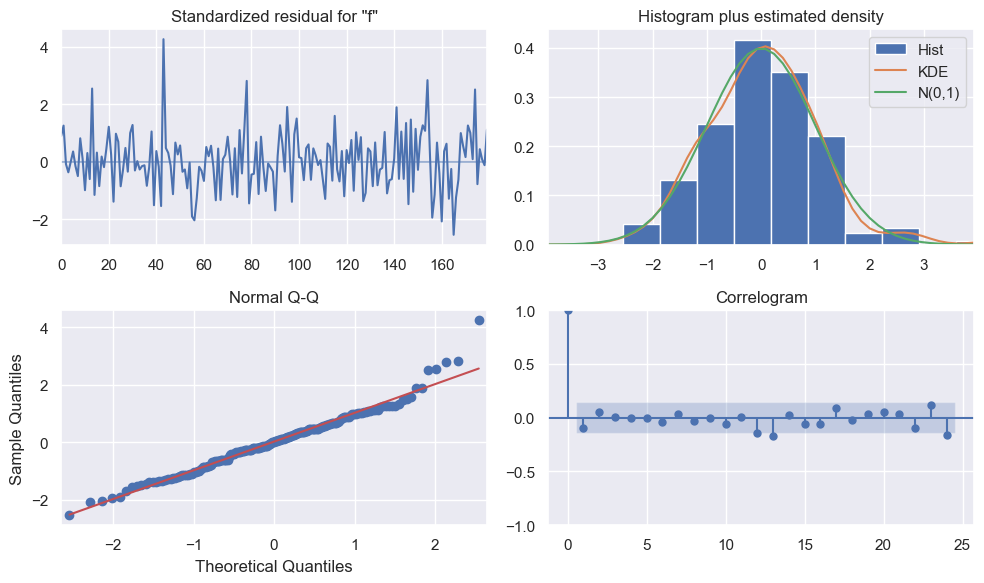

```python
model_3 = SARIMAX(diff, order=(12,0,0), seasonal_order=(0, 0, 0, 12))
model_3 = model_3.fit(disp=False)
print(model_3.summary())

model_3.plot_diagnostics(lags=24,figsize=(10, 6))
plt.tight_layout()
plt.show()
```

##### Model 4 - SARIMAX (0, 0, 1) (1, 1, 0, 12)

```
                                      SARIMAX Results
===========================================================================================
Dep. Variable:                             finance   No. Observations:                  180
Model:             SARIMAX(0, 0, 1)x(1, 1, [], 12)   Log Likelihood                -468.408
Date:                             Mon, 19 Feb 2024   AIC                            942.816
Time:                                     14:36:54   BIC                            952.188
Sample:                                          0   HQIC                           946.620
                                             - 180
Covariance Type:                               opg
==============================================================================
                 coef    std err          z      P>|z|      [0.025      0.975]
------------------------------------------------------------------------------
ma.L1         -0.4335      0.060     -7.281      0.000      -0.550      -0.317
ar.S.L12      -0.6977      0.045    -15.363      0.000      -0.787      -0.609
sigma2        14.7247      1.437     10.244      0.000      11.907      17.542
===================================================================================
Ljung-Box (L1) (Q):                   0.00   Jarque-Bera (JB):                10.43
Prob(Q):                              0.98   Prob(JB):                         0.01
Heteroskedasticity (H):               1.15   Skew:                            -0.24
Prob(H) (two-sided):                  0.60   Kurtosis:                         4.12
===================================================================================

Warnings:
[1] Covariance matrix calculated using the outer product of gradients (complex-step).
```

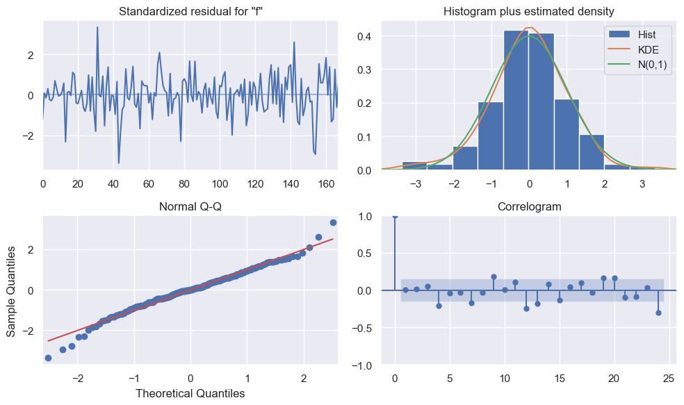

```python
model_4 = SARIMAX(diff, order=(0,0,1), seasonal_order=(1,1,0, 12))
model_4 = model_4.fit(disp=False)
print(model_4.summary())

model_4.plot_diagnostics(lags=24,figsize=(10, 6))
plt.tight_layout()
plt.show()
```

##### Model 5 - SARIMAX (1, 0, 0) (1, 1, 0, 12)

```
                                     SARIMAX Results
==========================================================================================
Dep. Variable:                            finance   No. Observations:                  180
Model:             SARIMAX(1, 0, 0)x(1, 1, 0, 12)   Log Likelihood                -470.313
Date:                            Mon, 19 Feb 2024   AIC                            946.626
Time:                                    14:37:04   BIC                            955.998
Sample:                                         0   HQIC                           950.430
                                            - 180
Covariance Type:                              opg
==============================================================================
                 coef    std err          z      P>|z|      [0.025      0.975]
------------------------------------------------------------------------------
ar.L1         -0.3719      0.066     -5.678      0.000      -0.500      -0.244
ar.S.L12      -0.7090      0.045    -15.695      0.000      -0.798      -0.620
sigma2        15.0337      1.525      9.861      0.000      12.046      18.022
===================================================================================
Ljung-Box (L1) (Q):                   0.60   Jarque-Bera (JB):                 6.23
Prob(Q):                              0.44   Prob(JB):                         0.04
Heteroskedasticity (H):               1.09   Skew:                            -0.14
Prob(H) (two-sided):                  0.74   Kurtosis:                         3.90
===================================================================================

Warnings:
[1] Covariance matrix calculated using the outer product of gradients (complex-step).
```

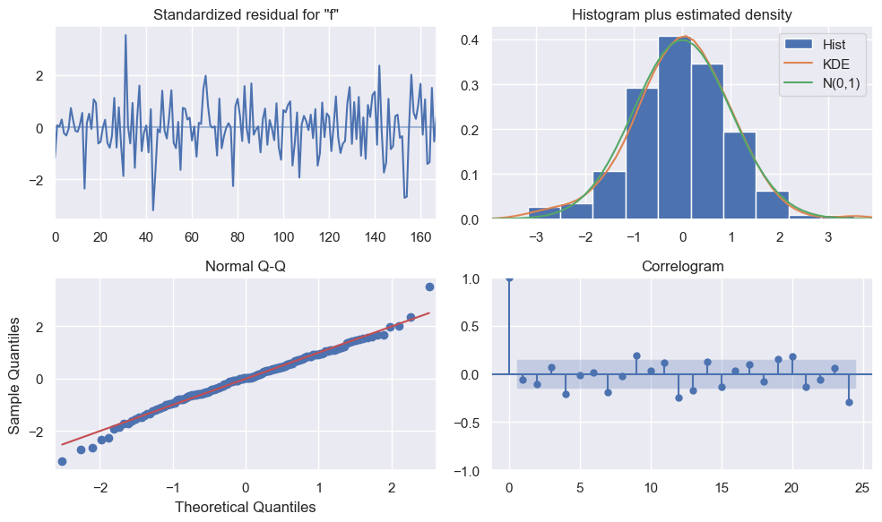

```python
model_5 = SARIMAX(diff, order=(1,0,0), seasonal_order=(1,1, 0, 12))
model_5 = model_5.fit(disp=False)
print(model_5.summary())

model_5.plot_diagnostics(lags=24,figsize=(10, 6))
plt.tight_layout()
plt.show()
```

### 1.e

```python
def res_plot(model,model_name):
    model_df = pd.DataFrame(model.resid.iloc[12:], columns = ['error']).reset_index()

    fig, ax = plt.subplots(figsize=(16,5))
    plt.scatter(x=model_df['index'], y=model_df["error"])
    plt.axhline(y=0, color="#C21292", linestyle="--",linewidth=2)
    props = dict(facecolor='#C21292', edgecolor='black', boxstyle='round,pad=0.2',alpha=.7)
    plt.text(0.95,0.9,f"BIC: {round(model.bic,4)}",fontsize=14,color='white',va='center',ha='center', bbox=props, transform=ax.transAxes)
    plt.title(f"SARIMAX\n\n{model_name}")
    plt.tight_layout()
    plt.show()
```

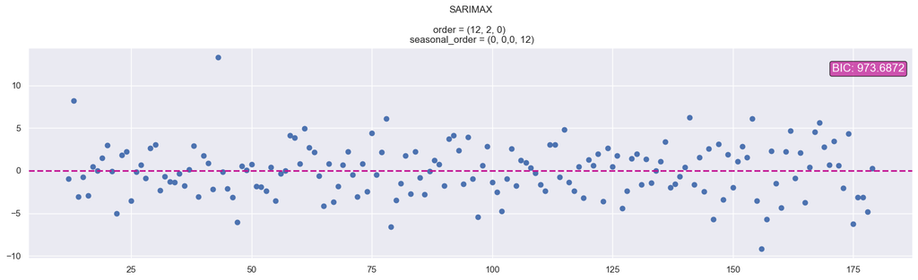

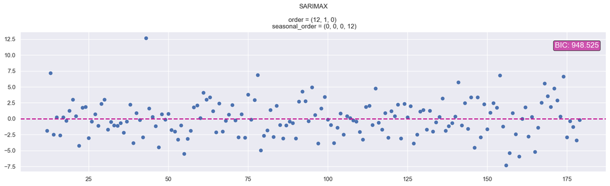

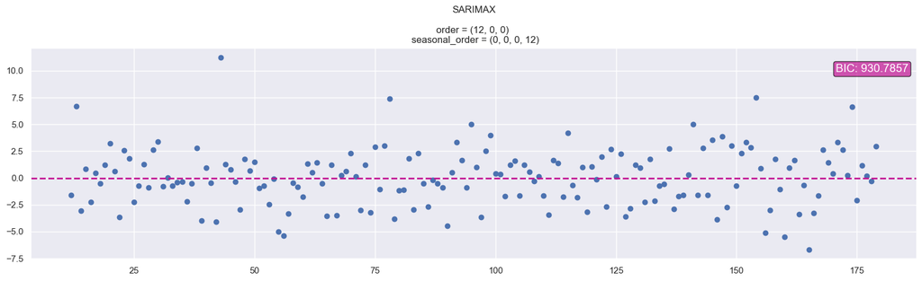

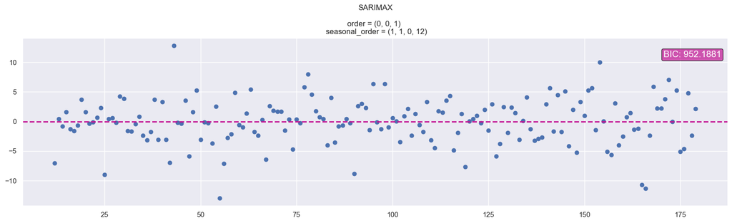

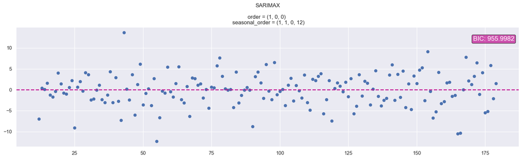

```python
res_plot(model_1,"order = (12, 2, 0) \n seasonal_order = (0, 0,0, 12)")
res_plot(model_2,"order = (12, 1, 0) \n seasonal_order = (0, 0, 0, 12)")
res_plot(model_3,"order = (12, 0, 0) \n seasonal_order = (0, 0, 0, 12)")
res_plot(model_4,"order = (0, 0, 1) \n seasonal_order = (1, 1, 0, 12)")
res_plot(model_5,"order = (1, 0, 0) \n seasonal_order = (1, 1, 0, 12)")
```

## **Question 2**

#### Define DataFrame

```python
q2_data = pd.read_csv('baseball_popularity.csv', parse_dates=['month'])
date_range = pd.date_range(start = '2004-01-01',end='2022-05-01',freq='MS')
q2_data.set_index(date_range,inplace=True)
q2_data['y'] = q2_data.baseball
q2_data['ds'] = q2_data.month
df = q2_data[['ds','y']]
q2_data = q2_data.drop(['month','y','ds'],axis=1)
```

### 2.a

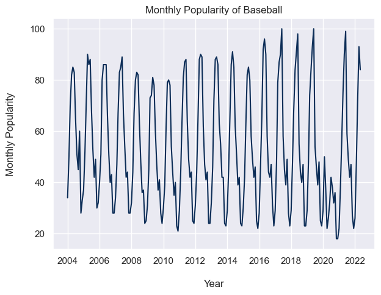

```python
sns.lineplot(data = q2_data, x= q2_data.index , y="baseball", linewidth=1.5,color='#0C2D57')
plt.xlabel('\nYear')
plt.ylabel("Monthly Popularity\n")
plt.tight_layout()
plt.title('Monthly Popularity of Baseball')
```

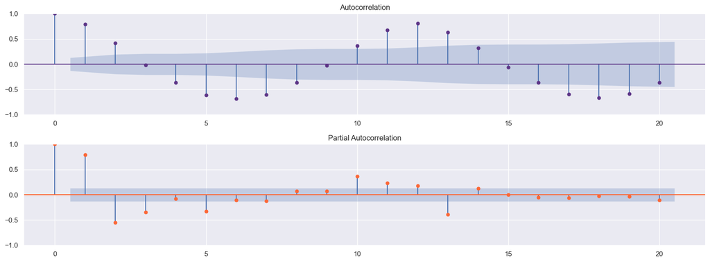

```python
fig, axes = plt.subplots(2,1,figsize=(16, 6))

tsaplots.plot_acf(q2_data, lags=20, color='#5D3587', ax=axes[0])
tsaplots.plot_pacf(q2_data, lags=20, color='#FC6736', ax=axes[1])
fig.tight_layout()
fig.show()
```

ACF doesn't converge to threshold interval, thus series is not stationary.

### 2.b

```python
def check_stationary(data:pd.DataFrame, decomposition_period = 12):
    sns.lineplot(data = data, x='index' , y="baseball", linewidth=1.5,color='#0C2D57')
    plt.xlabel('\nYear')
    plt.ylabel("Monthly Popularity\n")
    plt.tight_layout()
    plt.title('Monthly Popularity of Baseball \n(Stationarity)')
    plt.show()

    _, pvalue,_,_,_,_ = adfuller(data['baseball'],autolag='AIC')
    print(f"P-value for transformed data stationary check:\n{pvalue}")


    decomposition = seasonal_decompose(x=data['baseball'], model='additive', period = decomposition_period)
    decomposition.plot()

    fig, axes = plt.subplots(2,1,figsize=(20, 10))

    tsaplots.plot_acf(data['baseball'], lags=60, color='#5D3587', ax=axes[0])
    tsaplots.plot_pacf(data['baseball'], lags=60, color='#FC6736', ax=axes[1])
    fig.show()
```

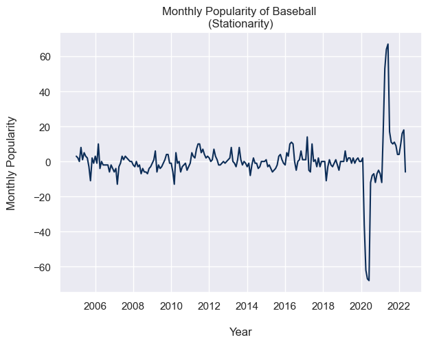

```
P-value for transformed data stationary check:
0.0006057464584896449
```

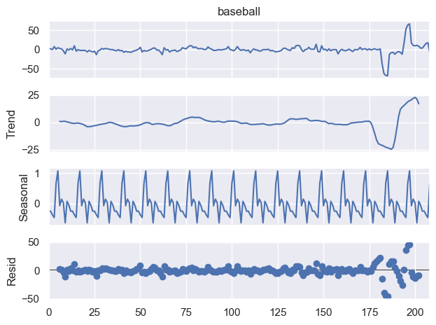

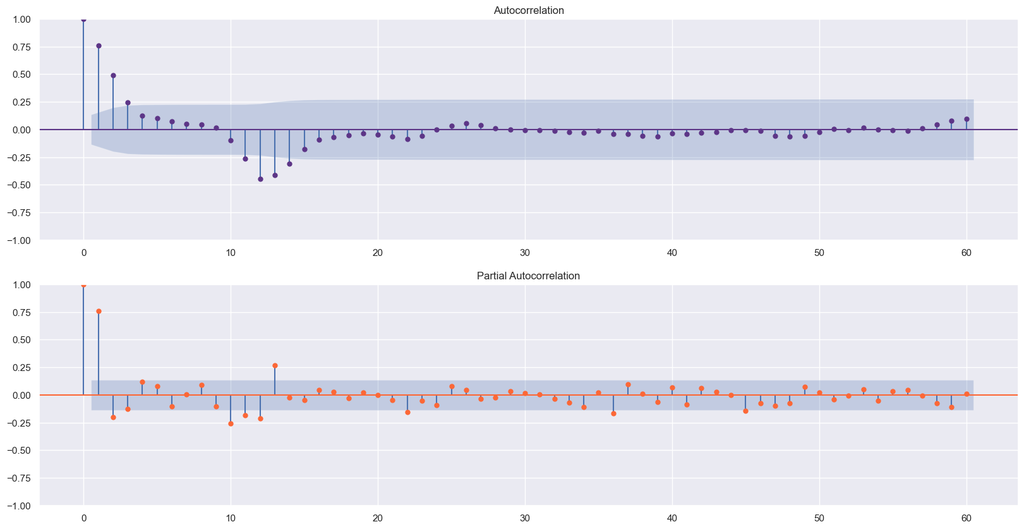

```python
seasonal_diff = (q2_data.diff(periods=12)).dropna(inplace=False)
diff_data = seasonal_diff.reset_index()
check_stationary(diff_data)
```

### 2.c

We can observe that when lag = 3 the PACF is almost 0. We will select the AR p-values by when the PACF spikes significantly different from the 0 line for the first time, i.e. p = 2.

### 2.d

```
14:46:17 - cmdstanpy - INFO - Chain [1] start processing
14:46:17 - cmdstanpy - INFO - Chain [1] done processing
```

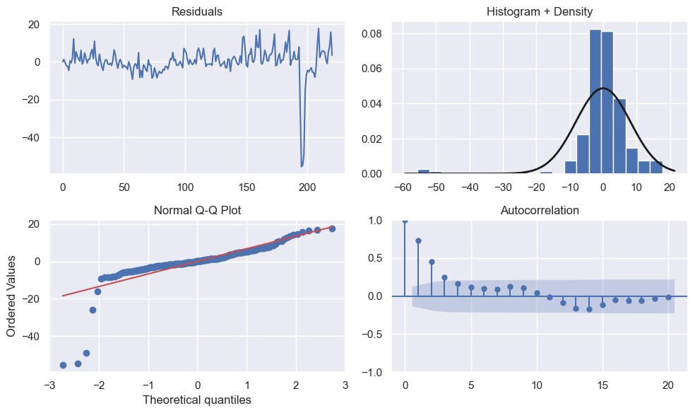

```python
from prophet import Prophet

q2_data["y"] = q2_data["baseball"]
q2_data["ds"] = q2_data.index

model = Prophet(seasonality_mode='additive').fit(q2_data)
future = model.make_future_dataframe(periods=365)
forecast = model.predict(future)

residuals = [true-pred for true,pred in zip (q2_data['y'], forecast['yhat'][:len(q2_data)])]

fig, axes = plt.subplots(2, 2, figsize=(10, 6))
axes = axes.flatten()

axes[0].plot(residuals)

axes[1].hist(residuals, bins=20, density=True)
xmin, xmax = axes[1].get_xlim()
x = np.linspace(xmin, xmax, 100)
p = stats.norm.pdf(x, np.mean(residuals), np.std(residuals))
axes[1].plot(x, p, 'k', linewidth=2)

stats.probplot(residuals, dist="norm", plot=axes[2])
tsaplots.plot_acf(residuals, ax=axes[3], lags=20)


axes[0].set_title('Residuals')
axes[1].set_title('Histogram + Density')
axes[2].set_title('Normal Q-Q Plot')
axes[3].set_title('Autocorrelation')

plt.tight_layout()
plt.show()
```

### 2.e

```python
def model_results(model):
    print(model.summary())
    model.plot_diagnostics(lags=24,figsize=(10, 6))
    plt.tight_layout()
    plt.show()
```

```python
def res_plot(model,model_name):
    model_df = pd.DataFrame(model.resid.iloc[12:], columns = ['error']).reset_index()

    fig, ax = plt.subplots(figsize=(16,5))
    plt.scatter(x=model_df['index'], y=model_df["error"])
    plt.axhline(y=0, color="#C21292", linestyle="--",linewidth=2)
    props = dict(facecolor='#C21292', edgecolor='black', boxstyle='round,pad=0.2',alpha=.7)
    plt.text(0.95,0.9,f"BIC: {round(model.bic,4)}",fontsize=14,color='white',va='center',ha='center', bbox=props, transform=ax.transAxes)
    plt.title(f"SARIMAX\n\n{model_name}")
    plt.tight_layout()
    plt.show()
```

```python
diff = q2_data['baseball']
```

```
                                      SARIMAX Results
============================================================================================
Dep. Variable:                             baseball   No. Observations:                  221
Model:             SARIMAX(2, 0, 0)x(0, 1, [1], 12)   Log Likelihood                -677.977
Date:                              Mon, 19 Feb 2024   AIC                           1363.953
Time:                                      14:56:49   BIC                           1377.323
Sample:                                  01-01-2004   HQIC                          1369.359
                                       - 05-01-2022
Covariance Type:                                opg
==============================================================================
                 coef    std err          z      P>|z|      [0.025      0.975]
------------------------------------------------------------------------------
ar.L1          0.8749      0.030     29.149      0.000       0.816       0.934
ar.L2         -0.1696      0.038     -4.418      0.000      -0.245      -0.094
ma.S.L12      -0.8372      0.031    -26.859      0.000      -0.898      -0.776
sigma2        35.7500      1.658     21.565      0.000      32.501      38.999
===================================================================================
Ljung-Box (L1) (Q):                   0.02   Jarque-Bera (JB):              1040.22
Prob(Q):                              0.88   Prob(JB):                         0.00
Heteroskedasticity (H):               4.81   Skew:                            -1.56
Prob(H) (two-sided):                  0.00   Kurtosis:                        13.47
===================================================================================

Warnings:
[1] Covariance matrix calculated using the outer product of gradients (complex-step).
```

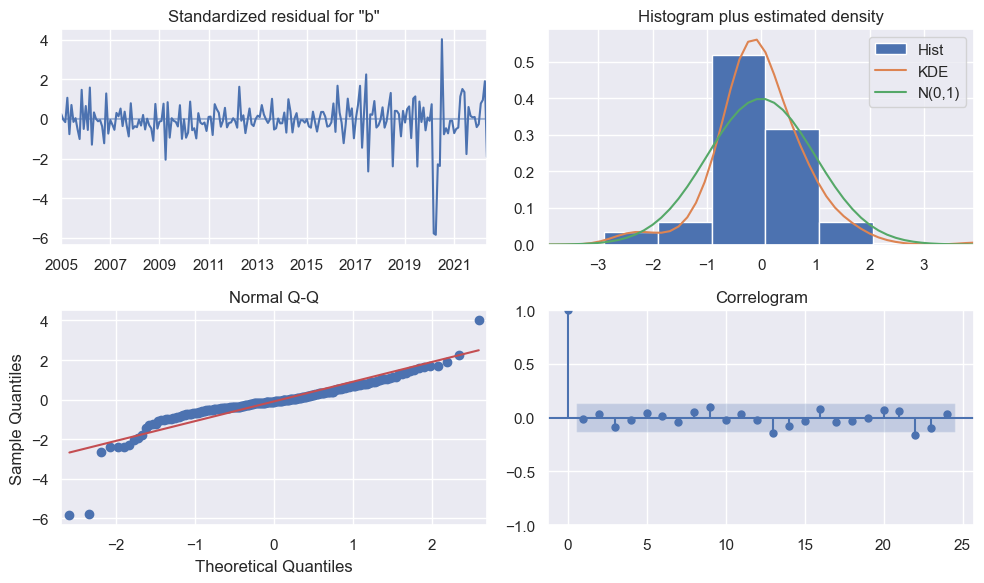

[figure not shown]

```python
model_1 = SARIMAX(diff, order=(2, 0, 0),seasonal_order=(0, 1, 1,12))
model_1 = model_1.fit(disp=False)

model_results(model_1)
res_plot(model_1,"order = (2, 0, 0) \n seasonal_order = (0, 1, 0, 12)")
```

```
                                        SARIMAX Results
===============================================================================================
Dep. Variable:                                baseball   No. Observations:                  221
Model:             SARIMAX(0, 1, 0)x(2, 0, [1, 2], 12)   Log Likelihood                -739.585
Date:                                 Mon, 19 Feb 2024   AIC                           1489.171
Time:                                         15:03:08   BIC                           1506.139
Sample:                                     01-01-2004   HQIC                          1496.023
                                          - 05-01-2022
Covariance Type:                                   opg
==============================================================================
                 coef    std err          z      P>|z|      [0.025      0.975]
------------------------------------------------------------------------------
ar.S.L12       0.4188      1.305      0.321      0.748      -2.140       2.977
ar.S.L24       0.5759      1.302      0.442      0.658      -1.975       3.127
ma.S.L12      -0.2838      1.322     -0.215      0.830      -2.874       2.307
ma.S.L24      -0.4514      1.118     -0.404      0.686      -2.642       1.739
sigma2        42.0924      1.869     22.523      0.000      38.430      45.755
===================================================================================
Ljung-Box (L1) (Q):                   0.38   Jarque-Bera (JB):              1412.67
Prob(Q):                              0.54   Prob(JB):                         0.00
Heteroskedasticity (H):               4.47   Skew:                            -0.23
Prob(H) (two-sided):                  0.00   Kurtosis:                        15.41
===================================================================================

Warnings:
[1] Covariance matrix calculated using the outer product of gradients (complex-step).
```

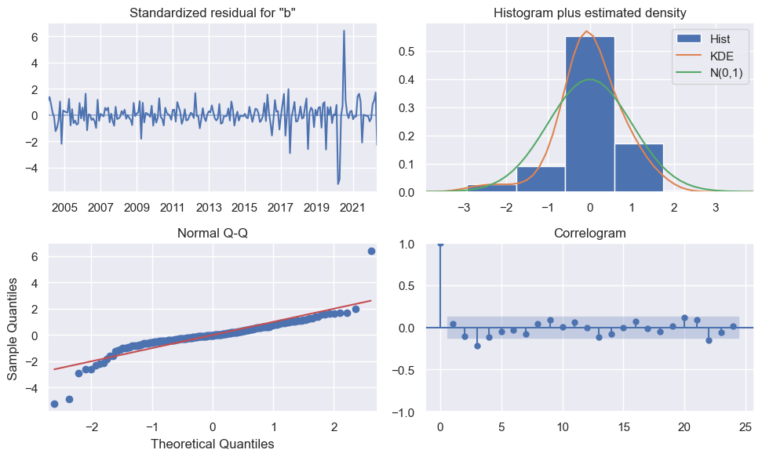

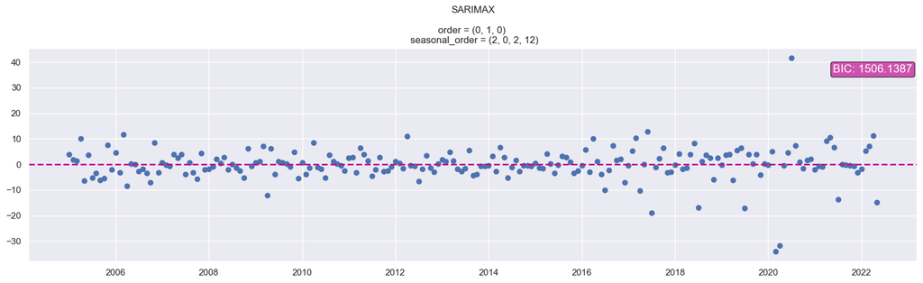

```python
model_2 = SARIMAX(diff, order=(0, 1, 0),seasonal_order=(2, 0, 2,12))
model_2 = model_2.fit(disp=False)

model_results(model_2)
res_plot(model_2,"order = (0, 1, 0) \n seasonal_order = (2, 0, 2, 12)")
```

```
                                     SARIMAX Results
==========================================================================================
Dep. Variable:                           baseball   No. Observations:                  221
Model:             SARIMAX(1, 0, 2)x(0, 0, 2, 12)   Log Likelihood                -800.873
Date:                            Mon, 19 Feb 2024   AIC                           1613.746
Time:                                    15:03:36   BIC                           1634.135
Sample:                                01-01-2004   HQIC                          1621.978
                                     - 05-01-2022
Covariance Type:                              opg
==============================================================================
                 coef    std err          z      P>|z|      [0.025      0.975]
------------------------------------------------------------------------------
ar.L1          0.8692      0.035     24.847      0.000       0.801       0.938
ma.L1          0.3983      0.069      5.738      0.000       0.262       0.534
ma.L2          0.2980      0.069      4.346      0.000       0.164       0.432
ma.S.L12       0.6136      0.054     11.460      0.000       0.509       0.719
ma.S.L24       0.6440      0.081      7.917      0.000       0.485       0.803
sigma2        75.9918      6.194     12.268      0.000      63.851      88.132
===================================================================================
Ljung-Box (L1) (Q):                   1.06   Jarque-Bera (JB):               138.05
Prob(Q):                              0.30   Prob(JB):                         0.00
Heteroskedasticity (H):               2.63   Skew:                            -0.86
Prob(H) (two-sided):                  0.00   Kurtosis:                         6.47
===================================================================================

Warnings:
[1] Covariance matrix calculated using the outer product of gradients (complex-step).
```

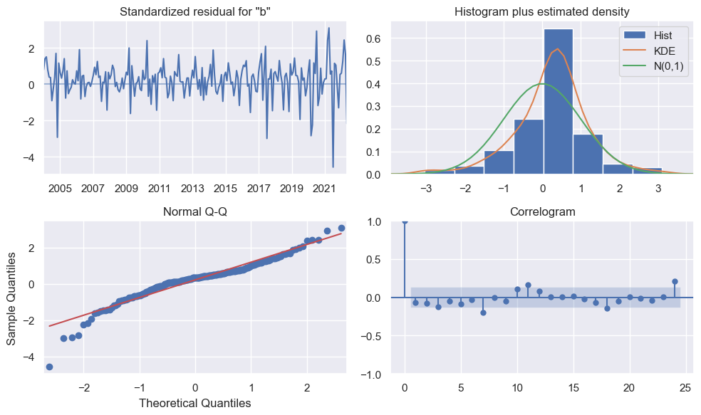

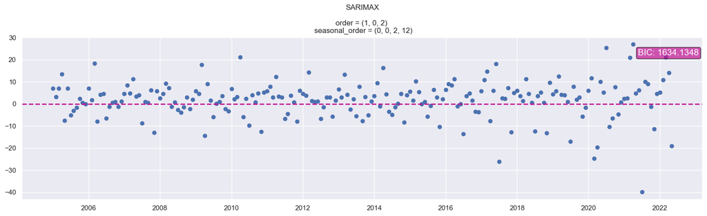

```python
model_3 = SARIMAX(diff, order=(1, 0, 2),seasonal_order=(0, 0,2,12))
model_3 = model_3.fit(disp=False)

model_results(model_3)
res_plot(model_3,"order = (1, 0, 2) \n seasonal_order = (0, 0, 2, 12)")
```

```
                                     SARIMAX Results
==========================================================================================
Dep. Variable:                           baseball   No. Observations:                  221
Model:             SARIMAX(1, 0, 0)x(1, 1, 0, 12)   Log Likelihood                -700.773
Date:                            Mon, 19 Feb 2024   AIC                           1407.546
Time:                                    15:03:52   BIC                           1417.573
Sample:                                01-01-2004   HQIC                          1411.600
                                     - 05-01-2022
Covariance Type:                              opg
==============================================================================
                 coef    std err          z      P>|z|      [0.025      0.975]
------------------------------------------------------------------------------
ar.L1          0.7745      0.014     53.688      0.000       0.746       0.803
ar.S.L12      -0.5286      0.030    -17.685      0.000      -0.587      -0.470
sigma2        46.7646      1.752     26.698      0.000      43.331      50.198
===================================================================================
Ljung-Box (L1) (Q):                   5.33   Jarque-Bera (JB):              1327.64
Prob(Q):                              0.02   Prob(JB):                         0.00
Heteroskedasticity (H):               6.95   Skew:                             0.08
Prob(H) (two-sided):                  0.00   Kurtosis:                        15.35
===================================================================================

Warnings:
[1] Covariance matrix calculated using the outer product of gradients (complex-step).
```

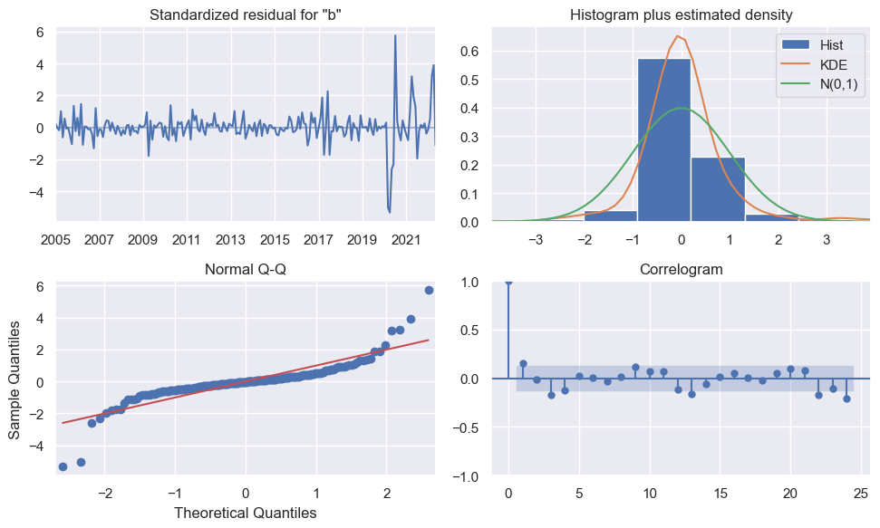

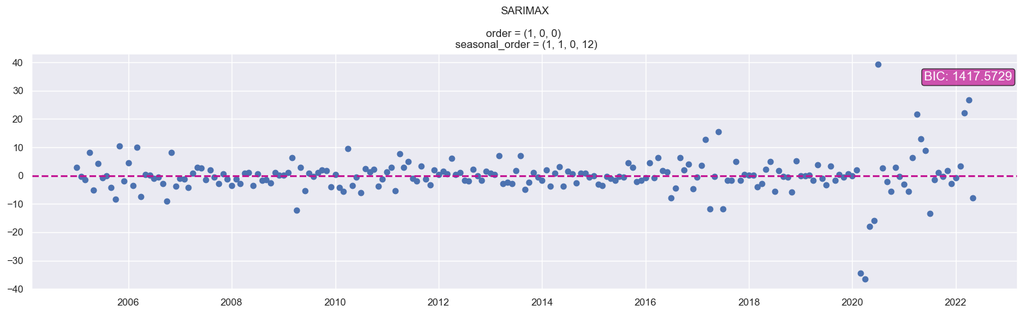

```python
model_4 = SARIMAX(diff, order=(1, 0, 0),seasonal_order=(1, 1, 0,12))
model_4 = model_4.fit(disp=False)

model_results(model_4)
res_plot(model_4,"order = (1, 0, 0) \n seasonal_order = (1, 1, 0, 12)")
```